# Reproducible Research: Project 1

# Mark Down for Peer Review

This an R markdown file generated for completion of the Coursera Reproducible Research Course Project 1. The following computations and visualizations are performed using the ggplot2, dplyr, and scales packages. https://www.coursera.org/learn/reproducible-research/.

# What is mean total number of steps taken per day?

The following code loads the file to a csv in the WD, converts date column to date datatype, and converts data set to a data frame.

```r
activity <- read.csv("activity.csv")

activity$date <- as.Date(activity$date, "%Y-%m-%d")
activity <- as.data.frame(activity)
```

Plots a histogram for step total by day using ggplot2

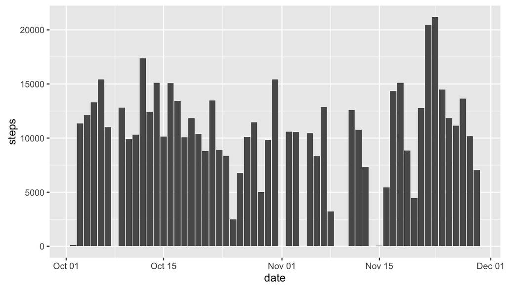

Calculates mean and median of steps take by day

```r
steps <- with(activity, tapply(steps, date, sum, na.rm = TRUE))

mean(steps)
```

```
## [1] 9354.23
```

```r
median(steps)
```

```
## [1] 10395
```

# What is the average daily activity pattern?

Using tapply, the means for each interval here are calculated across days.

```r
daymeans <- with(na.omit(activity), tapply(steps, interval, mean))
head(daymeans)
```

```
##         0         5        10        15        20        25
## 1.7169811 0.3396226 0.1320755 0.1509434 0.0754717 2.0943396
```

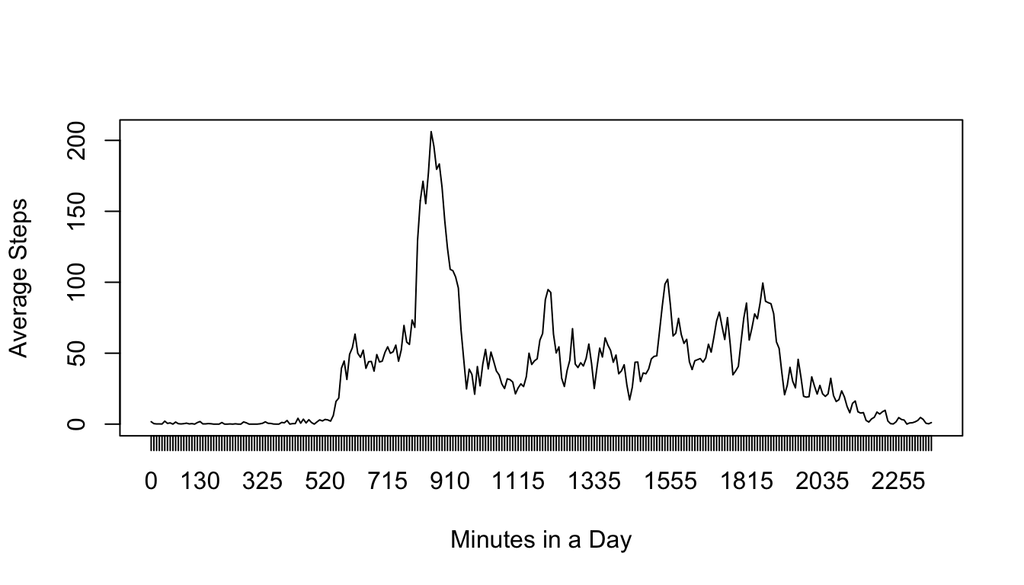

```r
daymeans[which(daymeans == max(daymeans))]
```

```
##      835
## 206.1698
```

The following sums the na values and then reports the ratio of NA/total observations.

```r
library(scales)
sum(is.na(activity))
```

```
## [1] 2304
```

```r
percent(sum(is.na(activity))/nrow(activity))
```

```
## [1] "13.1%"
```

# Imputing missing values

My strategy for replacing NAs is to replace each NA value by steps mean per interval. This is accomplished by using a nested for loop to identify the respective interval of the row then replace the NA value with the mean for that interval.

For demonstration purposes, the head and the tail of the data both contain NAs.

```r
head(activity)
```

```
##   steps       date interval
## 1    NA 2012-10-01        0
## 2    NA 2012-10-01        5
## 3    NA 2012-10-01       10
## 4    NA 2012-10-01       15
## 5    NA 2012-10-01       20
## 6    NA 2012-10-01       25
```

```r
tail(activity)
```

```
##       steps       date interval
## 17563    NA 2012-11-30     2330
## 17564    NA 2012-11-30     2335
## 17565    NA 2012-11-30     2340
## 17566    NA 2012-11-30     2345
## 17567    NA 2012-11-30     2350
## 17568    NA 2012-11-30     2355
```

The int and len variable are set up to manage the for loop sequences. The NAin and NA steps variables are sections of the data that will be used to replace the NA data after the loop.

```r
int <- unique(activity$interval)
len <- nrow(activity[is.na(activity),])

NAint <-  activity[is.na(activity),3]
NAsteps <- activity[is.na(activity),1]

for (j in 1:2304) {
       for (i in 1:288){
              if (NAint[j] == int[i])
                     NAsteps[j] <- daymeans[i]

       }
}

NAindex <- is.na(activity$steps)
activity$steps<- replace(activity$steps,NAindex, NAsteps)
```

As can be seen here, the NAs have been replaced by the relevant mean for the 5 minute interval.

```r
head(activity)
```

```
##       steps       date interval
## 1 1.7169811 2012-10-01        0
## 2 0.3396226 2012-10-01        5
## 3 0.1320755 2012-10-01       10
## 4 0.1509434 2012-10-01       15
## 5 0.0754717 2012-10-01       20
## 6 2.0943396 2012-10-01       25
```

```r
tail(activity)
```

```
##           steps       date interval
## 17563 2.6037736 2012-11-30     2330
## 17564 4.6981132 2012-11-30     2335
## 17565 3.3018868 2012-11-30     2340
## 17566 0.6415094 2012-11-30     2345
## 17567 0.2264151 2012-11-30     2350
## 17568 1.0754717 2012-11-30     2355
```

Below is an histogram with the updated data.

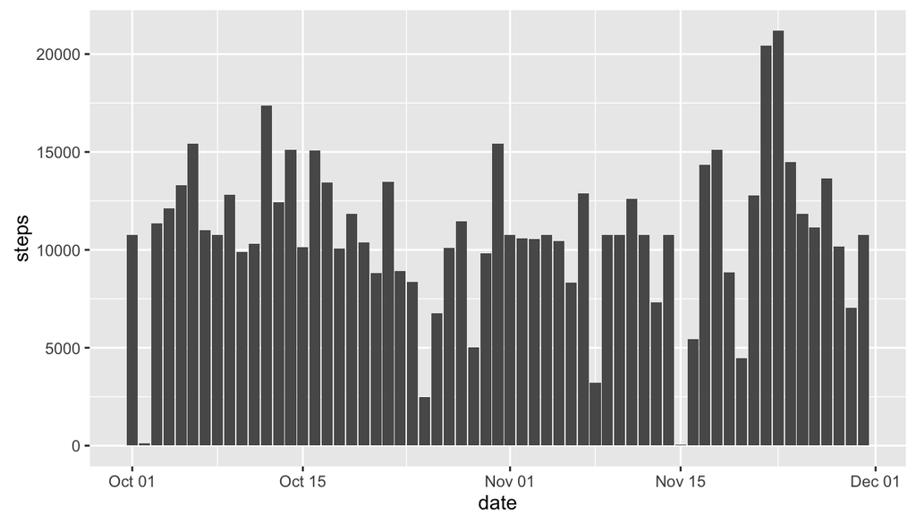

Calculates mean and median of steps take by day

```r
steps <- with(activity, tapply(steps, date, sum, na.rm = TRUE))

mean(steps)
```

```
## [1] 10766.19
```

```r
median(steps)
```

```
## [1] 10766.19
```

Do these values differ from the estimates from the first part of the assignment? What is the impact of imputing missing data on the estimates of the total daily number of steps?

Yes they are changed, because the NAs were replaced based on the interval means, the mean and the median for the day now match up.

# Are there differences in activity patterns between weekdays and weekends?

First, this code creates a new factor variable.

```r
library(dplyr)
activity <- mutate(activity, day = weekdays(activity$date))

weekdays <- c('Monday', 'Tuesday', 'Wednesday', 'Thursday', 'Friday')

activity$day <- factor((weekdays(activity$date) %in% weekdays),
         levels=c(FALSE, TRUE), labels=c('Weekend', 'Weekday'))
```

```r
weekdays <- subset(activity, day == "Weekday")
weekends <- subset(activity, day == "Weekend")

weekendmeans <- with(weekends, tapply(steps, interval, mean))
weekdaymeans <- with(weekdays, tapply(steps, interval, mean))
```

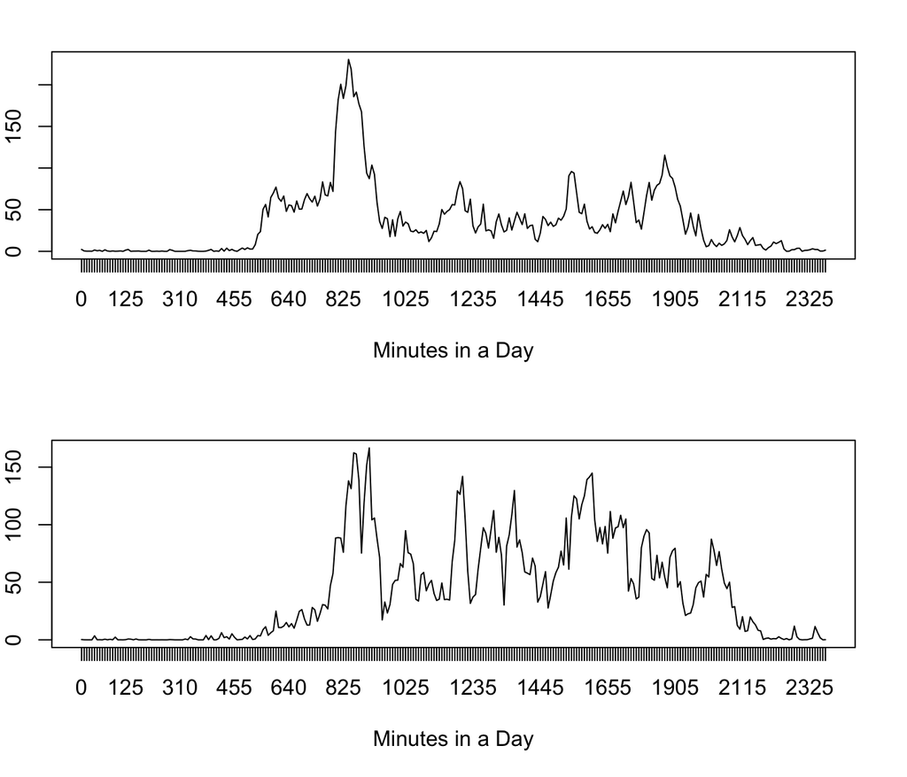